# Homework_5

Ziad Al Bkhetan

October 30, 2015

# Data Loading

```r
wines_def <- read.table("http://archive.ics.uci.edu/ml/machine-learning-databases/wine-quality/winequality-red.csv", sep=";", header=TRUE)
head(wines_def)
```

```
##   fixed.acidity volatile.acidity citric.acid residual.sugar chlorides
## 1           7.4             0.70        0.00            1.9     0.076
## 2           7.8             0.88        0.00            2.6     0.098
## 3           7.8             0.76        0.04            2.3     0.092
## 4          11.2             0.28        0.56            1.9     0.075
## 5           7.4             0.70        0.00            1.9     0.076
## 6           7.4             0.66        0.00            1.8     0.075
##   free.sulfur.dioxide total.sulfur.dioxide density   pH sulphates alcohol
## 1                  11                   34  0.9978 3.51      0.56     9.4
## 2                  25                   67  0.9968 3.20      0.68     9.8
## 3                  15                   54  0.9970 3.26      0.65     9.8
## 4                  17                   60  0.9980 3.16      0.58     9.8
## 5                  11                   34  0.9978 3.51      0.56     9.4
## 6                  13                   40  0.9978 3.51      0.56     9.4
##   quality
## 1       5
## 2       5
## 3       5
## 4       6
## 5       5
## 6       5
```

# Data Preparation

in this phase we will create categorical variables for the continuse variables in two different ways:  
* subranges with the same length, but maybe each subrange has differnt number of samples, using cut function  
* subranges with the same number of samples inside each of them, but they have different lengths, using cut2 function and parameter g = 3  
* in both cases we will have three subranges for variables values.  
* for the target attribute we will create categorical variable with two different values good and bad, so we have binary classification problem.

```r
library(grid)
library(survival)
library(e1071)
library(caret)
library(randomForest)
library(MASS)
library(klaR)
library(Hmisc)
```

```r
library (gplots)
library(rpart)

wines <- wines_def
wines$quality <- factor(ifelse(wines_def$quality > 5, "good", "bad"))
wines_equal_length <- wines
for (i in 1:11) {
  wines_equal_length[,i] <- cut(wines[,i], 3)
}
summary(wines_equal_length)
```

```
##      fixed.acidity      volatile.acidity         citric.acid
##  (4.59,8.37]:969   (0.119,0.607]:1098    (-0.001,0.333]:1009
##  (8.37,12.1]:572   (0.607,1.09] : 493    (0.333,0.667] : 555
##  (12.1,15.9]: 58   (1.09,1.58]  :   8    (0.667,1]     :  35
##       residual.sugar          chlorides      free.sulfur.dioxide
##  (0.885,5.77]:1540   (0.0114,0.212]:1560   (0.929,24.7]:1289
##  (5.77,10.6] :  48   (0.212,0.411] :  28   (24.7,48.3] : 292
##  (10.6,15.5] :  11   (0.411,0.612] :  11   (48.3,72.1] :  18
##  total.sulfur.dioxide          density               pH
##  (5.72,100]:1472      (0.99,0.995] : 171   (2.74,3.16]: 267
##  (100,195] : 125      (0.995,0.999]:1270   (3.16,3.59]:1269
##  (195,289] :   2      (0.999,1]    : 158   (3.59,4.01]:  63
##          sulphates           alcohol    quality
##  (0.328,0.887]:1482   (8.39,10.6]:985   bad :744
##  (0.887,1.44] : 109   (10.6,12.7]:559   good:855
##  (1.44,2]     :   8   (12.7,14.9]: 55
```

```r
wines_equal_size <- wines
for (i in 1:11) {
  wines_equal_size[,i]<- cut2(wines[,i], g=3)
}
summary(wines_equal_size)
```

```
##     fixed.acidity      volatile.acidity      citric.acid
##  [4.6, 7.5):574   [0.120,0.440):555     [0.00,0.16):538
##  [7.5, 8.9):525   [0.440,0.605):540     [0.16,0.37):528
##  [8.9,15.9]:500   [0.605,1.580]:504     [0.37,1.00]:533
##       residual.sugar         chlorides   free.sulfur.dioxide
##  [0.90, 2.05):620    [0.012,0.075):571   [ 1,11):605
##  [2.05, 2.50):460    [0.075,0.086):498   [11,19):486
##  [2.50,15.50]:519    [0.086,0.611]:530   [19,72]:508
##  total.sulfur.dioxide          density              pH
##  [ 6, 27):534         [0.990,0.996):534   [2.74,3.26):550
##  [27, 53):545         [0.996,0.997):545   [3.26,3.38):529
##  [53,289]:520         [0.997,1.004]:520   [3.38,4.01]:520
##        sulphates          alcohol    quality
##  [0.33,0.58):535   [ 8.4, 9.8):552   bad :744
##  [0.58,0.69):542   [ 9.8,10.9):531   good:855
##  [0.69,2.00]:522   [10.9,14.9]:516
```

```r
indxTrain <- createDataPartition(y = wines_equal_size$quality, p = 0.8)
wines_equal_sizeTrain<- wines_equal_size[indxTrain$Resample1,]
wines_equal_sizeTest <- wines_equal_size[-indxTrain$Resample1,]

indxTrain <- createDataPartition(y = wines_equal_length$quality, p = 0.8)
wines_equal_lengthTrain<- wines_equal_length[indxTrain$Resample1,]
wines_equal_lengthTest <- wines_equal_length[-indxTrain$Resample1,]
```

# Naive Bayes Classifier for ranges with the same length

we will applay naive bayse for dataset with equal subranges length, using a model containing all attributes.

```r
nbc <- naiveBayes(quality~., data=wines_equal_lengthTrain)
pred_same_length <- predict(nbc, wines_equal_lengthTest)
confusionMatrix(pred_same_length, wines_equal_lengthTest$quality)
```

```
## Confusion Matrix and Statistics
##
##           Reference
## Prediction bad good
##       bad  104   51
##       good  44  120
##
##                Accuracy : 0.7022
##                  95% CI : (0.6487, 0.7519)
##     No Information Rate : 0.5361
##     P-Value [Acc > NIR] : 1e-09
##
##                   Kappa : 0.4032
##  Mcnemar's Test P-Value : 0.5382
##
##             Sensitivity : 0.7027
##             Specificity : 0.7018
##          Pos Pred Value : 0.6710
##          Neg Pred Value : 0.7317
##              Prevalence : 0.4639
##          Detection Rate : 0.3260
##    Detection Prevalence : 0.4859
##       Balanced Accuracy : 0.7022
##
##        'Positive' Class : bad
##
```

# Naive Bayes Classifier for ranges with the same size

we will applay naive bayse for dataset with same number of samples in each subrange, using a model containing all attributes.

```r
nbc <- naiveBayes(quality~., data=wines_equal_sizeTrain)
pred_same_size <- predict(nbc, wines_equal_sizeTest)
confusionMatrix(pred_same_size, wines_equal_sizeTest$quality)
```

```
## Confusion Matrix and Statistics
##
##           Reference
## Prediction bad good
##       bad  101   43
##       good  47  128
##
##                Accuracy : 0.7179
##                  95% CI : (0.665, 0.7666)
##     No Information Rate : 0.5361
##     P-Value [Acc > NIR] : 2.228e-11
##
##                   Kappa : 0.4318
##  Mcnemar's Test P-Value : 0.7518
##
##             Sensitivity : 0.6824
##             Specificity : 0.7485
##          Pos Pred Value : 0.7014
##          Neg Pred Value : 0.7314
##              Prevalence : 0.4639
##          Detection Rate : 0.3166
##    Detection Prevalence : 0.4514
##       Balanced Accuracy : 0.7155
##
##        'Positive' Class : bad
##
```

# important Variables using random forests

I tried to find the important variables in the dataset for the original dataset, and the two datasets after converting the attributes to categorical attributes, and I noticed that the importance of some variables were changed when their values changed from continuse to categorical. you can check the results to see

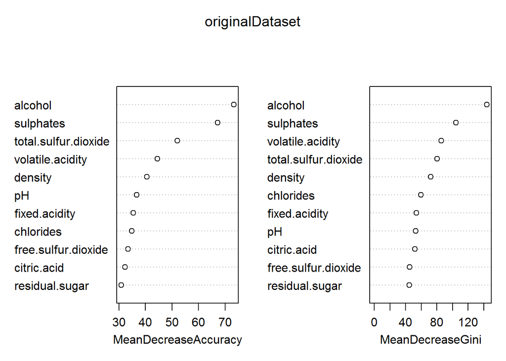

```r
# Default Dataset
originalDataset <- randomForest(quality~. ,data=wines, importance=TRUE)
varImpPlot(originalDataset)
```

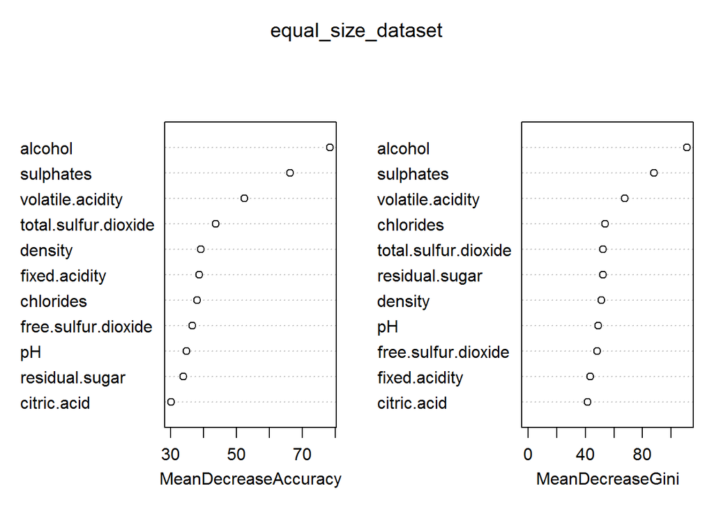

```r
# Equal Size Dataset
equal_size_dataset <- randomForest(quality~. ,data=wines_equal_size, importance=TRUE)
varImpPlot(equal_size_dataset)
```

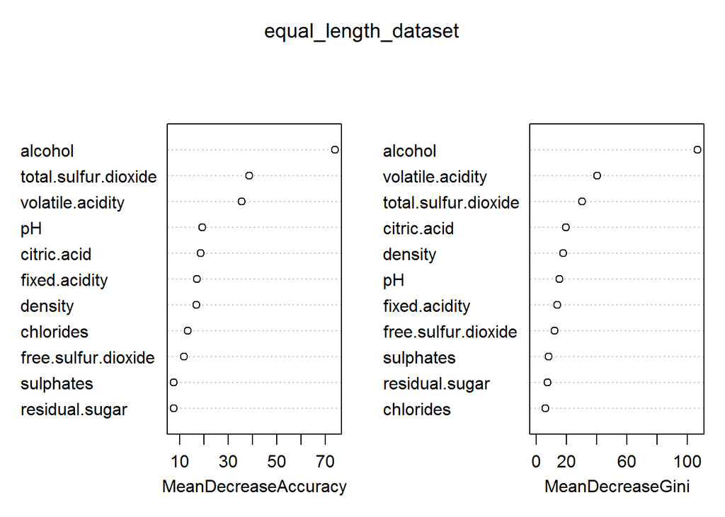

```r
# Equal length Dataset
equal_length_dataset <- randomForest(quality~. ,data=wines_equal_length, importance=TRUE)
varImpPlot(equal_length_dataset)
```